# hw4

## 使用packages

```r
library(NLP)
library(tm)
library(tmcn)
Sys.setenv(JAVA_HOME = "C:/Program Files/Java/jdk-9.0.1/")
library(rJava)
library(SnowballC)
library(slam)
library(Matrix)
library(ggplot2)
library(plotly)
library(stats)
```

## 使用資料

本次作業延續作業三所使用之資料，續做文字之於文章間的關連度分析。 作業三網址：https://ntu-csx-datascience.github.io/R05H41010/hw3.html

## Term Document Matrix

首先建立一個字詞在各文章出現次數的Term Document Matrix，再來我對於與「七六人」這支球隊相關性高的幾個詞有興趣，因此以直方圖查看有哪些詞彙以及相關的程度。

從直方圖可以看出，在提到七六人這支球隊時，作者也常常提及他賦予期待的球員Ben Simmons以及球隊的口號TrustTheProcess，甚至作者認為這支球隊的組成已經預約偉大，因此偉大這個詞也常常伴隨在提及七六人隊的文章當中。

```r
d.corpus <- Corpus(VectorSource(seg))
tdm <- TermDocumentMatrix(d.corpus,
       control = list(wordLengths = c(2, Inf)))
#Term Document Matrix
tdm1 <- as.matrix(tdm)
tdm1[21:31,1:10]
```

```
##         Docs
## Terms    1 2 3 4 5 6 7 8 9 10
##   上     1 0 3 1 2 9 1 7 3  4
##   大     3 0 0 1 4 3 1 2 0  0
##   小     1 0 0 0 0 0 1 1 0  0
##   已經   1 0 5 0 5 2 1 3 1  2
##   中     2 0 1 0 0 3 5 4 0  1
##   中距離 1 0 7 0 1 1 2 1 0  6
##   中樞   1 0 0 0 0 0 0 0 0  0
##   中鋒   1 0 0 0 0 0 0 0 0  0
##   之     1 0 0 0 2 0 0 0 0  0
##   之\xa4 1 0 0 0 0 1 1 0 0  0
##   之所以 1 0 0 0 0 0 0 0 0  0
```

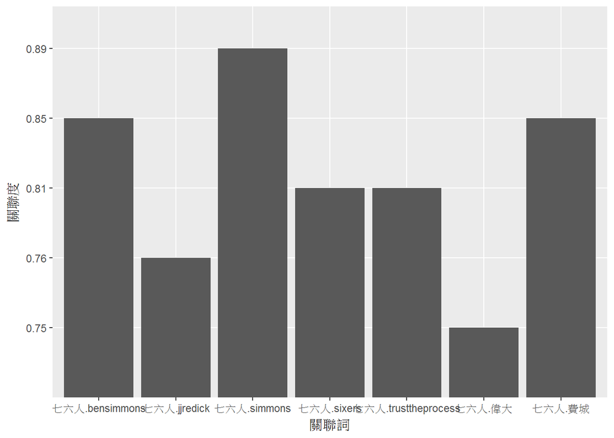

```r
ass = findAssocs(tdm, "七六人", 0.75)
gogo <- unlist(ass)
go1 <- cbind(names(gogo),gogo)
go1 <- as.data.frame(go1)
ggplot(go1,aes(x=V1,y=gogo))+geom_bar(stat='identity')+labs(x='關聯詞',y='關聯度')
```

## TF-IDF

接著建立TF-IDF矩陣，也就是查看每個字詞與每篇文章的相關程度。

由TF-IDF矩陣得以繪製下圖，即呈現一些與七六人隊高度相關的字詞分別於第幾篇文章出現，其中橫軸越往右代表著距今越久以前的文章。由圖可以看出，近期的文章較以前頻繁的提到七六人隊的相關內容，因此推論最新這一賽季的七六人隊得到作者的高度關注，並且由Ben Simmons這位球員出現的頻率與「偉大」出現的重合度推論，這位球員是作者這季非常關注的新星（與我長期關注此粉專的感受相同）。

```r
N = tdm$ncol
tf <- apply(tdm, 2, sum)
idfCal <- function(word_doc)
{
  log2( N / nnzero(word_doc) )
}
idf <- apply(tdm, 1, idfCal)

doc.tfidf <- as.matrix(tdm)
for(x in 1:nrow(tdm))
{
  for(y in 1:ncol(tdm))
  {
    doc.tfidf[x,y] <- (doc.tfidf[x,y] / tf[y]) * idf[x]
  }
}
topID = lapply(rownames(as.data.frame(ass)), function(x)
  which(rownames(tdm) == x))
topID = unlist(topID)


plot_ly(data = as.data.frame(doc.tfidf),
        x = as.numeric(colnames(doc.tfidf)),
        y = doc.tfidf[topID[2],],
        name = rownames(doc.tfidf)[topID[2]],
        type = "scatter", mode= "box") %>%
add_trace(y = doc.tfidf[topID[5],],
          name = rownames(doc.tfidf)[topID[5]]) %>%
add_trace(y = doc.tfidf[topID[7],],
          name = rownames(doc.tfidf)[topID[7]])
```

[interactive chart not shown]

## K-means 分群

最後將這100篇文章進行分群，分群的軸分別為「全能」及「生澀」這兩個對比的詞彙，預期想分出「只提到全能」、「只提到生澀」、「全能與生澀出現在同一篇文章」這三群，依此推論作者較常是客觀比較球員還是總是在批評，亦或總是在褒獎球員，因此我預期圖形為左邊一群、下面一群、右上方一群。

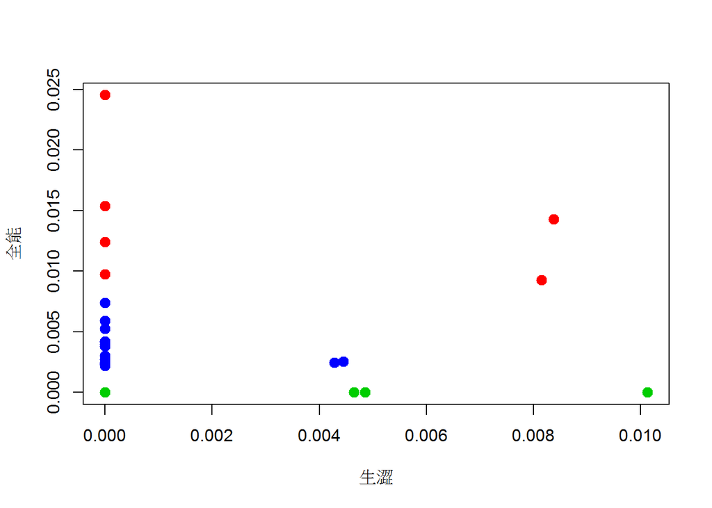

```r
tt <- t(doc.tfidf)
tt1 <- as.data.frame(tt)
ya <- tt1[,names(tt1) %in% c("全能","生澀")]
kmeansOut <- kmeans(ya, 3, nstart = 40)
plot(ya,col=(kmeansOut$cluster+1),pch=20,cex=2)
```